# **Practical Lab 8 - Fashion MNIST Classification with Dense Neural Networks**

[Visit github page](https://github.com/imdarshik/CSCN8010-labs/tree/main/week8)

### **1. Introduction**

In this notebook, we will explore the Fashion MNIST (fMNIST) dataset and build a fully-connected feedforward neural network using Keras and Tensorflow to classify different fashion items. The primary objective is to conduct an extensive Exploratory Data Analysis (EDA), train the dense network model, evaluate its performance using test data, and draw relevant conclusions.

```python
# Import necessary libraries
from tensorflow import keras  # Importing TensorFlow's Keras API
from tensorflow.keras import layers  # Importing layers module from Keras
import tensorflow as tf  # Importing TensorFlow library
import pandas as pd  # Importing pandas library for data manipulation
import numpy as np  # Importing NumPy library for numerical computations
import matplotlib.pyplot as plt  # Importing matplotlib library for plotting
import seaborn as sns  # Importing seaborn library for visualization
import warnings  # Importing warnings library to handle warnings
warnings.filterwarnings("ignore")  # Suppressing warnings
from sklearn.model_selection import train_test_split  # Importing train_test_split function
from sklearn.metrics import accuracy_score, precision_score, recall_score, f1_score  # Importing evaluation metrics
```

### **2. Data Acquisition and Preparation**

We will begin by obtaining the fMNIST dataset from Kaggle. The data will be loaded as numpy arrays from the CSV files. [Link to the data source](https://www.kaggle.com/datasets/zalando-research/fashionmnist/data)

```python
# Load the training Fashion MNIST
df_train = pd.read_csv("data/fashion-mnist_train.csv")
df_train.head()
```

|  | label | pixel1 | pixel2 | pixel3 | pixel4 | pixel5 | pixel6 | pixel7 | pixel8 | pixel9 | ... | pixel775 | pixel776 | pixel777 | pixel778 | pixel779 | pixel780 | pixel781 | pixel782 | pixel783 | pixel784 |
| --- | --- | --- | --- | --- | --- | --- | --- | --- | --- | --- | --- | --- | --- | --- | --- | --- | --- | --- | --- | --- | --- |
| 0 | 2 | 0 | 0 | 0 | 0 | 0 | 0 | 0 | 0 | 0 | ... | 0 | 0 | 0 | 0 | 0 | 0 | 0 | 0 | 0 | 0 |
| 1 | 9 | 0 | 0 | 0 | 0 | 0 | 0 | 0 | 0 | 0 | ... | 0 | 0 | 0 | 0 | 0 | 0 | 0 | 0 | 0 | 0 |
| 2 | 6 | 0 | 0 | 0 | 0 | 0 | 0 | 0 | 5 | 0 | ... | 0 | 0 | 0 | 30 | 43 | 0 | 0 | 0 | 0 | 0 |
| 3 | 0 | 0 | 0 | 0 | 1 | 2 | 0 | 0 | 0 | 0 | ... | 3 | 0 | 0 | 0 | 0 | 1 | 0 | 0 | 0 | 0 |
| 4 | 3 | 0 | 0 | 0 | 0 | 0 | 0 | 0 | 0 | 0 | ... | 0 | 0 | 0 | 0 | 0 | 0 | 0 | 0 | 0 | 0 |

5 rows × 785 columns

```python
# Load the test Fashion MNIST
df_test = pd.read_csv("data/fashion-mnist_test.csv")
df_test.head()
```

|  | label | pixel1 | pixel2 | pixel3 | pixel4 | pixel5 | pixel6 | pixel7 | pixel8 | pixel9 | ... | pixel775 | pixel776 | pixel777 | pixel778 | pixel779 | pixel780 | pixel781 | pixel782 | pixel783 | pixel784 |
| --- | --- | --- | --- | --- | --- | --- | --- | --- | --- | --- | --- | --- | --- | --- | --- | --- | --- | --- | --- | --- | --- |
| 0 | 0 | 0 | 0 | 0 | 0 | 0 | 0 | 0 | 9 | 8 | ... | 103 | 87 | 56 | 0 | 0 | 0 | 0 | 0 | 0 | 0 |
| 1 | 1 | 0 | 0 | 0 | 0 | 0 | 0 | 0 | 0 | 0 | ... | 34 | 0 | 0 | 0 | 0 | 0 | 0 | 0 | 0 | 0 |
| 2 | 2 | 0 | 0 | 0 | 0 | 0 | 0 | 14 | 53 | 99 | ... | 0 | 0 | 0 | 0 | 63 | 53 | 31 | 0 | 0 | 0 |
| 3 | 2 | 0 | 0 | 0 | 0 | 0 | 0 | 0 | 0 | 0 | ... | 137 | 126 | 140 | 0 | 133 | 224 | 222 | 56 | 0 | 0 |
| 4 | 3 | 0 | 0 | 0 | 0 | 0 | 0 | 0 | 0 | 0 | ... | 0 | 0 | 0 | 0 | 0 | 0 | 0 | 0 | 0 | 0 |

5 rows × 785 columns

```python
# Define a dictionary mapping integer labels to corresponding clothing item names
label_names = {
    0: 'T-shirt/top',
    1: 'Trouser',
    2: 'Pullover',
    3: 'Dress',
    4: 'Coat',
    5: 'Sandal',
    6: 'Shirt',
    7: 'Sneaker',
    8: 'Bag',
    9: 'Ankle boot'
}
```

```python
# Extract images and labels from DataFrame and reshape
# Convert DataFrame values to NumPy array, excluding the first column (labels)
# Reshape the remaining values into 28x28 images
# Convert the data type to unsigned 8-bit integer (uint8)
train_images, train_labels = df_train.values[:,1:].reshape((-1,28,28)).astype(np.uint8), df_train.values[:,0].astype(np.uint8)
test_images, test_labels = df_test.values[:,1:].reshape((-1,28,28)).astype(np.uint8), df_test.values[:,0].astype(np.uint8)
```

```python
# Dataset summary
print(f'Image DType: {type(train_images)}')
print(f'Image Element DType: {type(train_images[0,0,0])}')
print(f'Label Element DType: {type(train_labels[0])}')
print('**Shapes:**')
print('Train Data:')
print(f'Images: {train_images.shape}')
print(f'Labels: {train_labels.shape}')
print('Test Data:')
print(f'Images: {test_images.shape}')
print(f'Labels: {test_labels.shape}')
print('Image Data Range:')
print(f'Min: {train_images.min()}')
print(f'Max: {train_images.max()}')
```

```
Image DType: <class 'numpy.ndarray'>
Image Element DType: <class 'numpy.uint8'>
Label Element DType: <class 'numpy.uint8'>
**Shapes:**
Train Data:
Images: (60000, 28, 28)
Labels: (60000,)
Test Data:
Images: (10000, 28, 28)
Labels: (10000,)
Image Data Range:
Min: 0
Max: 255
```

### **3. Exploratory Data Analysis (EDA)**

#### **Fashion MNIST sample images from each class**

[figure not shown]

```python
# Initialize an empty dictionary to store fashion samples for each class
fashion_samples = {}

# Iterate over each fashion class (0 to 9)
for fashion in range(10):
    # Find the indices of training samples belonging to the current fashion class
    indices = np.where(train_labels == fashion)
    # Randomly select 10 samples from the current fashion class without replacement
    fashion_samples[fashion] = train_images[np.random.choice(indices[0], 10, replace=False)]

plt.figure(figsize=(11,11))
# Iterate over each fashion class and its corresponding samples
for fashion in range(100):
    plt.subplot(10, 10, fashion + 1)
    # Display the image corresponding to the fashion sample
    plt.imshow(fashion_samples[fashion // 10][fashion % 10], cmap=plt.cm.binary)
    # Set the title of the subplot to the name of the fashion class
    plt.title(label_names[fashion // 10])
    plt.axis('off')

plt.tight_layout()
plt.show()
```

#### **Average image for each fashion class**

Averaging images within each class provides a representative image that captures the typical characteristics of that class

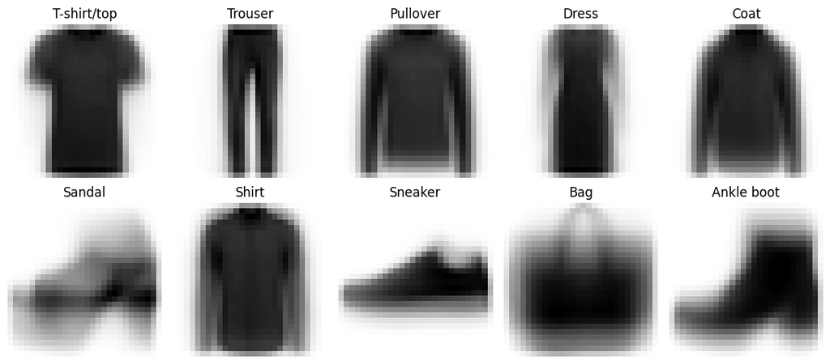

```python
# Reference: https://github.com/CSCN8010/CSCN8010/blob/main/class_notebooks/datasets/mnist.ipyn

# Create a figure to display the average image for each fashion class
plt.figure(figsize=(11,5))
# Iterate over each fashion class (0 to 9)
for fashion in range(10):
    # Find the indices of training samples belonging to the current fashion class
    fashion_indices = np.where(train_labels.astype('int8') == fashion)[0]
    # Compute the average image for the current fashion class by taking the mean across all samples
    avg_image = np.mean(train_images[fashion_indices], axis=0).reshape(28, 28)
    # Create a subplot for each fashion class
    plt.subplot(2,5,fashion+1)
    # Display the average image for the current fashion class
    plt.imshow(avg_image, cmap=plt.cm.binary)
    # Set the title of the subplot to the name of the fashion class
    plt.title(label_names[fashion])
    plt.axis('off')

plt.tight_layout()
plt.show()
```

The average image visualizations show that sandals, shoes and bags have more differences in their spatial layout compared to other classes. These differences appear as a slight blurriness that spreads across the images.

#### **Distance of images from the mean pixel values in each class**

We calculate the mean pixel values and compare the distances of each image from it in each class to understand how different images vary within the same category. This helps us see the diversity within each class and how individual images differ from the typical appearance of their class

```python
# Function to calculate Euclidean distance
def euclidean_distance(x1, x2):
    return np.sqrt(np.sum((x1 - x2)**2))

# Calculate mean pixel value for each digit
mean_instances = {}
for label in np.unique(train_labels):
    mean_instances[label] = np.mean(train_images[train_labels == label], axis=0)

# Calculate Euclidean distance for each image
euclidean_distances = np.zeros((len(train_images),))
for i, test_image in enumerate(train_images):
    label = train_labels[i]
    typical_instance = mean_instances[label]
    euclidean_distances[i] = euclidean_distance(test_image, typical_instance)
```

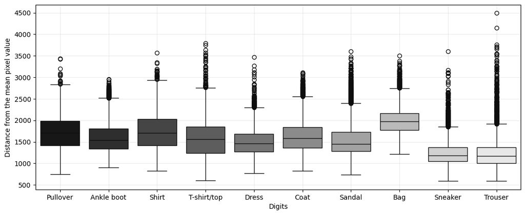

```python
# Reference: https://medium.com/@24100160/mnist-dataset-exploratory-data-analysis-of-handwritten-digits-classification-9fcc3793ea7b

# Create a figure to display the boxplot
plt.figure(figsize=(13,5))
# Create a boxplot with seaborn
# x-axis: Fashion class names corresponding to each label in the training labels
# y-axis: Euclidean distances calculated for each image
sns.boxplot(x=[label_names[label] for label in train_labels], y=euclidean_distances, palette="grey")
plt.xlabel("Digits")
plt.ylabel("Distance from the mean pixel value")
plt.grid(alpha=0.25)
plt.show()
```

The boxplot visualization of distances shows outliers in each class. These outliers represent images that stand out because they're quite different from the average image in their class. They might have unique styles or could be poorly captured images. Interestingly, **trousers** and **sneakers** have the most outliers.

#### **PLotting the outlier samples in each class**

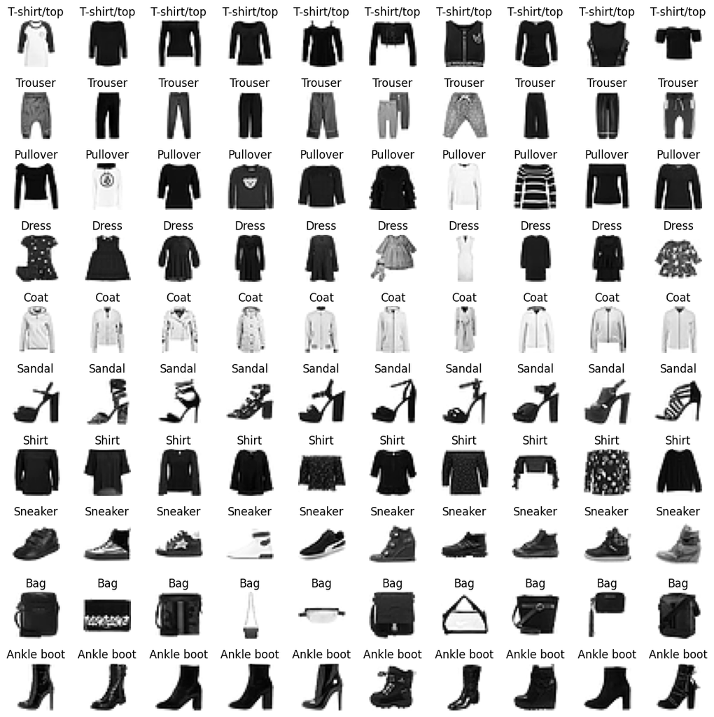

```python
# Define a function to calculate the interquartile range (IQR)
def IQR(dist):
    return np.percentile(dist, 75) - np.percentile(dist, 25)

# Initialize an empty dictionary to store outlier samples for each class
outlier_samples = {}

# Filter outliers in the digits dataset
for label in np.unique(train_labels):
    # Find the indices of samples belonging to the current class
    indices = np.where(train_labels == label)
    # Calculate the interquartile range (IQR) for the Euclidean distances of the current class
    iqr = IQR(euclidean_distances[indices])
    # Calculate the third quartile (Q3) for the Euclidean distances of the current class
    q3 = np.percentile(euclidean_distances[indices], 75)
    # Find outlier samples for the current class
    # Outliers are samples with Euclidean distances greater than Q3 + 1.5 * IQR
    outliers_ = train_images[indices][np.random.choice(np.where(euclidean_distances[indices] > (q3 + 1.5 * iqr))[0], 10, replace=False)]
    # Store the outlier samples for the current class in the dictionary
    outlier_samples[label] = outliers_

# Reference: https://medium.com/@24100160/mnist-dataset-exploratory-data-analysis-of-handwritten-digits-classification-9fcc3793ea7b

plt.figure(figsize=(11,11))
for fashion in range(100):
    # Create a subplot for each outlier sample
    plt.subplot(10,10,fashion+1)
    # Display the outlier image for the current class
    plt.imshow(outlier_samples[fashion // 10][fashion % 10], cmap=plt.cm.binary)
    # Set the title of the subplot to the name of the fashion class
    plt.title(label_names[fashion // 10])
    plt.axis('off')
plt.tight_layout()
plt.show()
```

Looking at the outlier images, we can see that the outlier boots are much taller than the common ones. For sneakers, the outliers are mostly midcut shoes. Sandals appear to have very tall and high heels. Lastly, trousers show a variety of designs, with some being shorter in length.

#### **Average pixel intensity in each class**

We calculate the average pixel intensity in each class to understand how bright or dark the typical images are within that class. This helps us see if there are any consistent differences in brightness between different categories of images

```python
# Calculate pixel intensity for each digit
pixel_intensity = {}
for label in np.unique(train_labels):
    pixel_intensity[label_names[label]] = np.mean(train_images[train_labels == label])
```

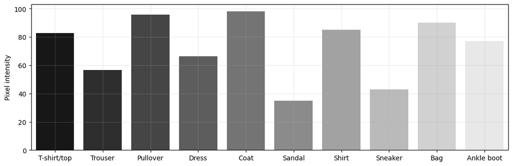

```python
# Reference: https://medium.com/@24100160/mnist-dataset-exploratory-data-analysis-of-handwritten-digits-classification-9fcc3793ea7b

plt.figure(figsize=(13,4))
sns.barplot(pixel_intensity, palette="grey")
plt.ylabel("Pixel intensity")
plt.grid(alpha=0.25)
plt.show()
```

Sandals and sneakers exhibit lower pixel intensity, indicating that these images are generally darker. On the other hand, shirts, pullovers, coats, and bags have higher pixel intensity, suggesting that these images are brighter overall

#### **Sample distribution across classes**

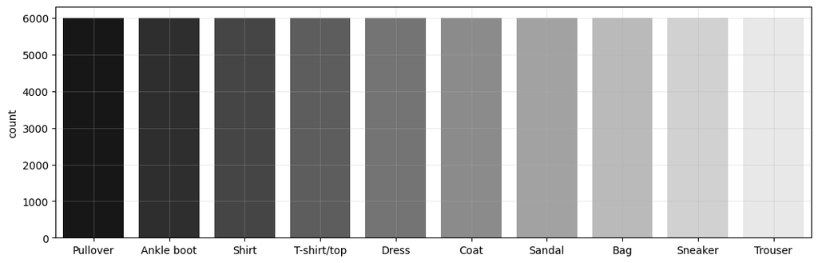

```python
plt.figure(figsize=(13,4))
sns.countplot(x=[label_names[label] for label in train_labels], palette="grey")
plt.grid(alpha=0.25)
plt.show()
```

The distribution graphs indicate that each class has an equal number of samples.

### **4. Model Development**

```python
# Split the dataset into training and validation sets using train_test_split function
X_train, X_val, y_train, y_val = train_test_split(train_images.reshape((60000, -1)), train_labels, test_size=0.2, stratify=train_labels, random_state=101)
print(X_train.shape)
print(X_val.shape)
print(y_train.shape)
print(y_val.shape)
```

```
(48000, 784)
(12000, 784)
(48000,)
(12000,)
```

```python
# Define a sequential model using Keras
model = keras.Sequential([
    # Add a fully connected dense layer with 256 units and ReLU activation function
    # Input shape is specified as (784,) for flattened images of size 28x28
    layers.Dense(256, activation='relu', input_shape=(784,)),

    # Add another fully connected dense layer with 256 units and ReLU activation function
    layers.Dense(256, activation='relu'),

    # Add the output layer with 10 units and softmax activation function
    # Softmax ensures that the output values represent probabilities of each class
    layers.Dense(10, activation='softmax')
])
```

```python
# Reference: https://github.com/CSCN8010/CSCN8010/blob/main/dl_class_notebooks/03A_minimal_mnist_keras.ipynb

# Compile the model with specified optimizer, loss function, and evaluation metrics
model.compile(optimizer="rmsprop",  # Using RMSprop optimizer
              loss="sparse_categorical_crossentropy",  # Using sparse categorical crossentropy loss function
              metrics=["accuracy"])  # Using accuracy as the evaluation metric

# Reference: https://www.kaggle.com/code/eslamhani/fashion-mnist

# Print a summary of the model architecture
model.summary()
```

```
Model: "sequential_1"
```

```
┏━━━━━━━━━━━━━━━━━━━━━━━━━━━━━━━━━┳━━━━━━━━━━━━━━━━━━━━━━━━┳━━━━━━━━━━━━━━━┓
┃ Layer (type)                    ┃ Output Shape           ┃       Param # ┃
┡━━━━━━━━━━━━━━━━━━━━━━━━━━━━━━━━━╇━━━━━━━━━━━━━━━━━━━━━━━━╇━━━━━━━━━━━━━━━┩
│ dense_3 (Dense)                 │ (None, 256)            │       200,960 │
├─────────────────────────────────┼────────────────────────┼───────────────┤
│ dense_4 (Dense)                 │ (None, 256)            │        65,792 │
├─────────────────────────────────┼────────────────────────┼───────────────┤
│ dense_5 (Dense)                 │ (None, 10)             │         2,570 │
└─────────────────────────────────┴────────────────────────┴───────────────┘
```

```
 Total params: 269,322 (1.03 MB)
```

```
 Trainable params: 269,322 (1.03 MB)
```

```
 Non-trainable params: 0 (0.00 B)
```

```python
# Define function to calculate precision, recall, and F1 score
def calculate_metrics(y_true, y_pred):
    accuracy = accuracy_score(y_true, y_pred)
    precision = precision_score(y_true, y_pred, average='weighted')
    recall = recall_score(y_true, y_pred, average='weighted')
    f1 = f1_score(y_true, y_pred, average='weighted')
    return round(accuracy, 4), round(precision, 4), round(recall, 4), round(f1, 4)
```

```python
# Training
h = model.fit(X_train, y_train, epochs=15, verbose=1, batch_size=128, shuffle=True)
```

```
375/375 ━━━━━━━━━━━━━━━━━━━━ 1s 2ms/step - accuracy: 0.6285 - loss: 25.0144
375/375 ━━━━━━━━━━━━━━━━━━━━ 1s 2ms/step - accuracy: 0.7329 - loss: 0.9259
375/375 ━━━━━━━━━━━━━━━━━━━━ 1s 2ms/step - accuracy: 0.7757 - loss: 0.7575
375/375 ━━━━━━━━━━━━━━━━━━━━ 1s 2ms/step - accuracy: 0.8073 - loss: 0.5916
375/375 ━━━━━━━━━━━━━━━━━━━━ 1s 2ms/step - accuracy: 0.8209 - loss: 0.5559
375/375 ━━━━━━━━━━━━━━━━━━━━ 1s 2ms/step - accuracy: 0.8349 - loss: 0.5096
375/375 ━━━━━━━━━━━━━━━━━━━━ 1s 2ms/step - accuracy: 0.8436 - loss: 0.4821
375/375 ━━━━━━━━━━━━━━━━━━━━ 1s 2ms/step - accuracy: 0.8491 - loss: 0.4500
375/375 ━━━━━━━━━━━━━━━━━━━━ 1s 2ms/step - accuracy: 0.8522 - loss: 0.4314
375/375 ━━━━━━━━━━━━━━━━━━━━ 1s 2ms/step - accuracy: 0.8615 - loss: 0.3972
375/375 ━━━━━━━━━━━━━━━━━━━━ 1s 2ms/step - accuracy: 0.8651 - loss: 0.3885
375/375 ━━━━━━━━━━━━━━━━━━━━ 1s 2ms/step - accuracy: 0.8652 - loss: 0.3839
375/375 ━━━━━━━━━━━━━━━━━━━━ 1s 2ms/step - accuracy: 0.8677 - loss: 0.3776
375/375 ━━━━━━━━━━━━━━━━━━━━ 1s 2ms/step - accuracy: 0.8758 - loss: 0.3576
375/375 ━━━━━━━━━━━━━━━━━━━━ 1s 2ms/step - accuracy: 0.8730 - loss: 0.3556
```

### **5. Model Evaluation**

```python
# Evaluate the model on the validation set
val_pred = model.predict(X_val)
val_pred = np.argmax(val_pred, axis=1)
```

```
375/375 ━━━━━━━━━━━━━━━━━━━━ 0s 757us/step
```

```python
# Calculate evaluation metrics
accuracy, precision, recall, f1 = calculate_metrics(y_val, val_pred)

print("Validation:")
print("Accuracy  :", accuracy)
print("Precision :", precision)
print("Recall    :", recall)
print("F1 Score  :", f1)
```

```
Validation:
Accuracy  : 0.8692
Precision : 0.8695
Recall    : 0.8692
F1 Score  : 0.8681
```

The model's performance on the validation set is as follows:

- Accuracy: About 87% of the validation set samples were classified correctly.
- Precision: Around 87% of the positive predictions made by the model were correct.
- Recall: The model correctly identified about 87% of all positive instances.
- F1 Score: This balanced measure of precision and recall is around 87%.

Overall, the model showed good performance on the validation set, achieving high accuracy and effectively identifying positive instances

### **6. Model testing**

```python
# Evaluate the model on the test set
test_pred = model.predict(test_images.reshape((10000, -1)))
test_pred = np.argmax(test_pred, axis=1)
```

```
313/313 ━━━━━━━━━━━━━━━━━━━━ 0s 913us/step
```

```python
# Calculate test metrics
accuracy, precision, recall, f1 = calculate_metrics(test_labels, test_pred)

print("Test:")
print("Accuracy  :", accuracy)
print("Precision :", precision)
print("Recall    :", recall)
print("F1 Score  :", f1)
```

```
Test:
Accuracy  : 0.8697
Precision : 0.869
Recall    : 0.8697
F1 Score  : 0.8681
```

These metrics show how well the model generalizes to new, unseen data

```python
from sklearn.metrics import precision_score, recall_score

# Calculate precision and recall for class 5
precision_class_5 = precision_score(test_labels, test_pred, labels=[5], average='macro')
recall_class_5 = recall_score(test_labels, test_pred, labels=[5], average='macro')
print("Precision for Class 5 :", round(precision_class_5, 4))
print("Recall for Class 5    :", round(recall_class_5, 4))
```

```
Precision for Class 5 : 0.97
Recall for Class 5    : 0.938
```

```python
# Evaluate the model on the test set
test_pred = model.predict(test_images.reshape((10000, -1)))
test_pred_labels = np.argmax(test_pred, axis=1)

# Adjust the decision threshold for class '5'
threshold = 0.75
class5_indices = np.where(test_pred_labels == 5)[0]
for ind in class5_indices:
    # Check if the predicted probability for class '5' is below the threshold
    if test_pred[ind][5] < threshold:
        test_pred_labels[ind] = -1
```

```
313/313 ━━━━━━━━━━━━━━━━━━━━ 0s 745us/step
```

```python
# Calculate precision for class 5
precision_class_5 = precision_score(test_labels, test_pred_labels, labels=[5], average='macro')
print("Precision for Class 5:", round(precision_class_5, 4))
```

```
Precision for Class 5: 0.9799
```

```python
# Evaluate the model on the test set
test_pred = model.predict(test_images.reshape((10000, -1)))
test_pred_labels = np.argmax(test_pred, axis=1)

# Adjust the decision threshold for class '5'
threshold = 0.2
class5_indices = np.where(test_pred_labels == 5)[0]
for ind in class5_indices:
    # Check if the predicted probability for class '5' is below the threshold
    if test_pred[ind][5] < threshold:
        test_pred_labels[ind] = -1
```

```
313/313 ━━━━━━━━━━━━━━━━━━━━ 0s 851us/step
```

```python
# Calculate recall for class 5
recall_class_5 = recall_score(test_labels, test_pred_labels, labels=[5], average='macro')
print("Recall for Class 5:", round(recall_class_5, 4))
```

```
Recall for Class 5: 0.938
```

The initial precision and recall for class '5' were **0.97** and **0.938**, respectively.

To increase precision, we adjusted the threshold to **0.75**, resulting in a precision of **0.9799** for class '5'.

However, for increasing recall, changing the threshold to **0.2** didn't result in a significant change in recall for class '5', which remained at **0.938**.

### **7. Conclusions**

- The model performed well on both training and testing data, showing high accuracy, precision, recall, and F1 score.
- Adjusting the threshold improved precision for class '5', but recall remained largely unchanged.
- While the model's performance was consistent, alternative strategies may be needed to boost recall without retraining.

Overall, the model showed strong performance, and targeted adjustments like threshold tuning can improve specific metrics, but further exploration may be needed for comprehensive enhancements.

```python
!jupyter nbconvert --to html Practical_lab8.ipynb
```